# Movie Rating Model and Predictor

# Part 1: Data

The data were comprised of audience and critics opinions, awards, studio, and actor information from Rotten Tomatoes and IMDB for a random sample of 651 movies produced and released prior to 2016.

## Data Sources

### Rotten Tomatoes

Launched in August 1998 by Senh Duong, Rotten Tomatoes is an American review aggregation website for film and television.

# Part 2: Research question

The underlying intent of this analysis was to determine the factors that most influence box office success for a film. Since box office revenue was not among the variables included in the raw data set, a popularity estimate was used as a proxy for box office success. Concretely,

> Which features most influence movie popularity

where:  
popularity is defined as 10 * imdb_rating + critics_score + audience_score

# Part 3: Exploratory data analysis

## Data Preprocessing

### Features

The full codebook for the data set can be found in Appendix A; however, Table 1 lists the data variables included at this stage in this study.  
Table 1: Exploratory data analysis features

| Variable | Description |
| --- | --- |
| **Response** |  |
| popularity | 10 x imdb_rating + critics_score + audience_score |
| **General** |  |
| title_type | Type of movie (Documentary, Feature Film, TV Movie) |
| genre | Genre of movie (Action & Adventure, Comedy, Documentary, Drama, Horror, Mystery & Suspense, Other) |
| mpaa_rating | MPAA rating of the movie (G, PG, PG-13, R, Unrated) |
| **Organization** |  |
| studio | Studio that produced the movie |
| director | Director of the movie |
| **Dates** |  |
| thtr_rel_season | Season the movie was released in theaters |
| thtr_rel_month | Month the movie is released in theaters |
| **Performance** |  |
| imdb_rating | Rating on IMDB |
| imdb_num_votes | Number of votes on IMDB |
| log_imdb_num_votes | Log number of IMDB votes |
| critics_score | Critics score on Rotten Tomatoes |
| audience_score | Audience score on Rotten Tomatoes |
| best_pic_nom | Whether or not the movie was nominated for a best picture Oscar (no, yes) |
| best_pic_win | Whether or not the movie won a best picture Oscar (no, yes) |
| best_actor_win | Whether or not one of the main actors in the movie ever won an Oscar (no, yes) – note that this is not necessarily whether the actor won an Oscar for their role in the given movie |
| best_actress win | Whether or not one of the main actresses in the movie ever won an Oscar (no, yes) – not that this is not necessarily whether the actresses won an Oscar for their role in the given movie |
| best_dir_win | Whether or not the director of the movie ever won an Oscar (no, yes) – not that this is not necessarily whether the director won an Oscar for the given movie |
| top200_box | Whether or not the movie is in the Top 200 Box Office list on BoxOfficeMojo (no, yes) |
| studio_votes | Total IMDB votes per studio |
| cast_votes | Total number of allocated IMDB votes for the cast of a film |
| **Experience** |  |
| studio_experience | Total number of films for studio in sample |
| director_experience | Total number of films in sample for a director |
| cast_experience | Relative experience in terms of the sum of the number of film in which each cast member appeared |

### Omitted Features

The features listed in Table 2 were not included for redundancy reasons or due to the lack of direct relevance to the research question. Some variables, such as the actor variables, were used to derive other variables which are further described below.

Table 2: Omitted features

| Variable | Description |
| --- | --- |
| title | Title of movie |
| runtime | Runtime of movie (in minutes) |
| imdb_url | Link to IMDB page for the movie |
| rt_url | Link to Rotten Tomatoes page for the movie |
| actor1 | First main actor/actress in the abridged cast of the movie |
| actor2 | Second main actor/actress in the abridged cast of the movie |
| actor3 | Third main actor/actress in the abridged cast of the movie |
| actor4 | Fourth main actor/actress in the abridged cast of the movie |
| actor5 | Fifth main actor/actress in the abridged cast of the movie |
| thtr_rel_year | Year the movie is released in theaters |
| thtr_rel_day | Day of the month the movie is released in theaters |
| dvd_rel_year | Year the movie is released on DVD |
| dvd_rel_month | Month the movie is released on DVD |
| dvd_rel_day | Day of the month the movie is released on DVD |
| critics_rating | Categorical variable for critics rating on Rotten Tomatoes (Certified Fresh, Fresh, Rotten) |
| audience_rating | Categorical variable for audience rating on Rotten Tomatoes (Spilled, Upright) |

### Data Cleaning

The variables of interest were obtained from the data and complete cases were extracted reducing the number of observations from 651 to 627.

### New Features

Six new variables were created to capture the popularity and experience of the studio, director and cast members.  
1. Movie Popularity  
2. Studio IMDB Votes  
3. Cast IMDB Votes  
4. Studio Experience  
5. Director Experience  
6. Cast Experience

Movie popularity was defined as 10 * imdb_rating + critics_score + audience_score. Studio IMDB votes was the total number of IMDB votes for each studio. Cast IMDB votes was the sum of the IMDB votes allocated to actors 1 thru 5 for each film. IMDB votes were allocated to cast members as follows:  
* 40% of total film IMDB votes for actor1  
* 30% of total film IMDB votes for actor2  
* 15% of total film IMDB votes for actor3  
* 10% of total film IMDB votes for actor4  
* 5% of total film IMDB votes for actor5

Each actor was allocated points accordingly, then the votes were aggregated for each film in which the cast member appeared. The IMDB votes were counted without regard for date to compensate for the limitations imposed by the sample size as movegoers had access to the population of reviews and director, studio, and actor performance data when making their purchase decision.

Studio, director and cast experience was the aggregate of the number of films in the sample in which the studio, director, or an actor was involved.

## Univariate Analysis

### Movie Popularity

Starting with the response variable, movie popularity was defined as 10 * imdb_rating + critics_score + audience_score. The summary statistics for movie popularity are:  
Table 3

| Min | Q1 | Median | Mean | Q3 | Max | NA.s | SD | IQR | Kurtosis | Skewness |
| --- | --- | --- | --- | --- | --- | --- | --- | --- | --- | --- |
| 38 | 144.5 | 185 | 184.1 | 231.5 | 284 | 0 | 54.75 | 87 | -0.82 | -0.32 |

As indicated by the kurtosis and skewness measures above, and as shown in Figure 1, the distribution of popularity score was multimodal and slightly left skewed.

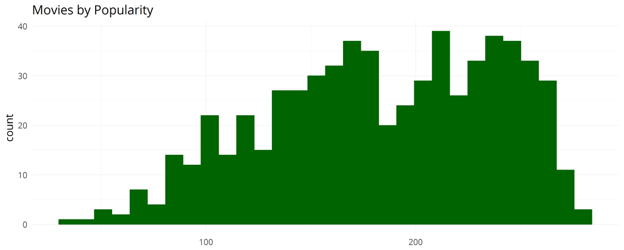

Figure 1: Distribution of movies by popularity

### Title Type

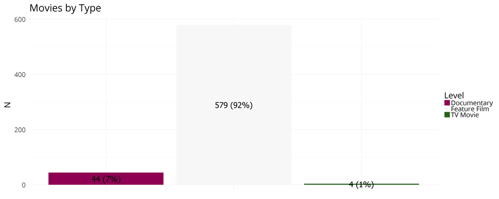

Figure 2: Films by title type

### Genre

The drama genre represented a plurality of the releases in the sample, followed by comedy action & adventure then mystery & suspense. The top four genres account for nearly 80% of the films in the sample.

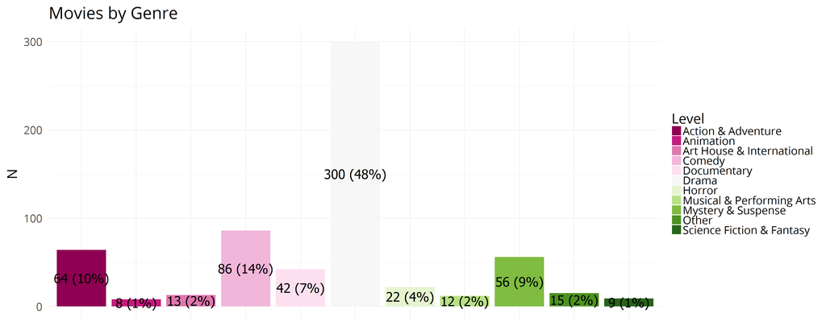

Figure 3: Films by genre

### MPAA Rating

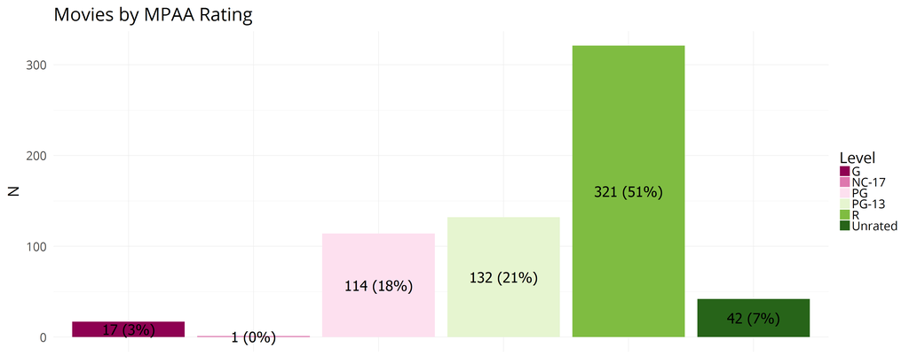

Figure 4: Films by MPAA Rating

### Studio

The data included films from 202 studios. Data with respect to the number of films in the sample per studio are provided in the Studio Experience section below.

### Director

The work of directors was included in the sample provided for this project. Data with respect to the number of films in the sample per director are provided in the Director Experience section below.

### Season of Theatrical Release

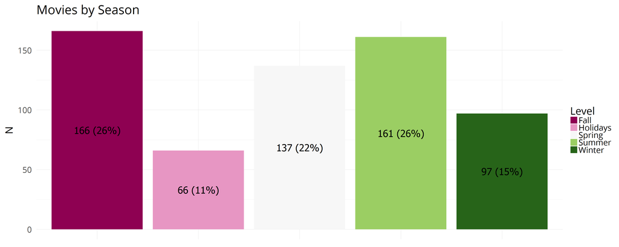

Figure 5: Theatrical releases by season

### Month of Theatrical Release

The plurality of features in the sample (42%) were released during the months of January, June, October and December. It was not evident that the sample reflects the population of movie releases in the United States.

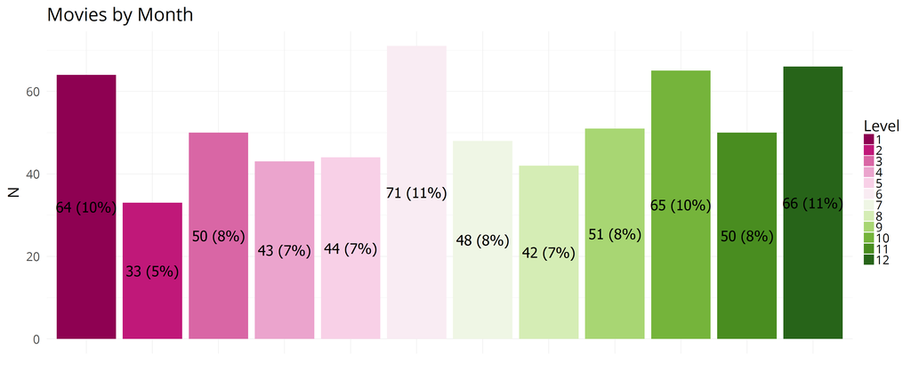

Figure 6: Theatrical releases by month

### Releases by IMDB Rating

IMDB rating is one of the variables that compose the popularity variable. Its summary statistics were:  
Table 4: Releases by IMDB rating

| Min | Q1 | Median | Mean | Q3 | Max | NA.s | SD | IQR | Kurtosis | Skewness |
| --- | --- | --- | --- | --- | --- | --- | --- | --- | --- | --- |
| 1.9 | 5.9 | 6.6 | 6.5 | 7.3 | 9 | 0 | 1.09 | 1.4 | 1.25 | -0.89 |

As indicated by the kurtosis and skewness measures above, and as shown in Figure 7, the distribution of ratings was unimodal slightly left skewed.

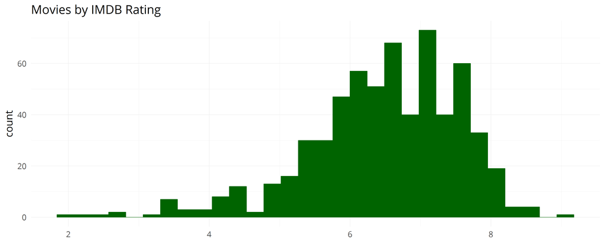

Figure 7: Theatrical releases by IMDB Rating

### IMDB Number of Votes

The summary statistics for IMDB votes are:  
Table 5: Summary statistics for IMDB Votes

| Min | Q1 | Median | Mean | Q3 | Max | NA.s | SD | IQR | Kurtosis | Skewness |
| --- | --- | --- | --- | --- | --- | --- | --- | --- | --- | --- |
| 183 | 4986 | 15806 | 59291.3 | 60409 | 893008 | 0 | 113763.6 | 55423 | 19.36 | 3.98 |

As indicated by the kurtosis and skewness measures above, and as shown in Figure 8, the distribution of ratings is heavily right skewed.

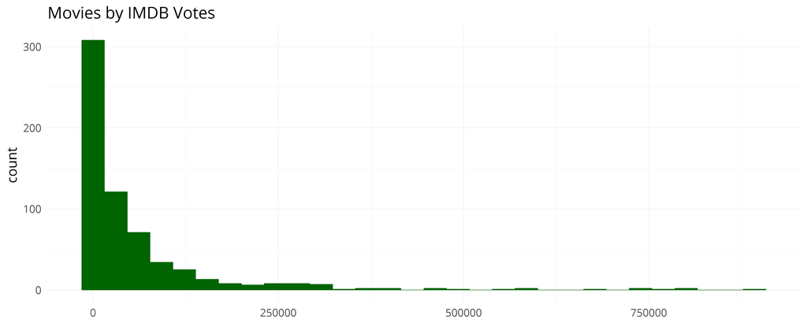

Figure 8: IMDB Votes

### IMDB Log Votes

To address the extreme skewness in the IMDB votes variable, a log transformation was performed with the following descriptive statistics.

Table 6 IMDB log votes summary statistics

| Min | Q1 | Median | Mean | Q3 | Max | NA.s | SD | IQR | Kurtosis | Skewness |
| --- | --- | --- | --- | --- | --- | --- | --- | --- | --- | --- |
| 7.5 | 12.3 | 13.9 | 14.1 | 15.9 | 19.8 | 0 | 2.37 | 3.6 | -0.58 | 0.04 |

Figure 9 evinces a nearly normal distribution for the log of IMDB votes.

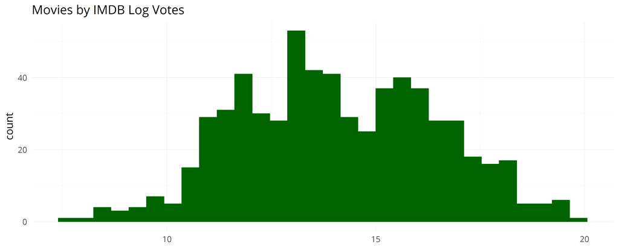

### Rotten Tomatoes Critics Scores

The summary statistics for Rotten Tomatoes critics scores were:  
Table 7

| Min | Q1 | Median | Mean | Q3 | Max | NA.s | SD | IQR | Kurtosis | Skewness |
| --- | --- | --- | --- | --- | --- | --- | --- | --- | --- | --- |
| 1 | 33 | 61 | 57.2 | 82 | 100 | 0 | 28.38 | 49 | -1.19 | -0.25 |

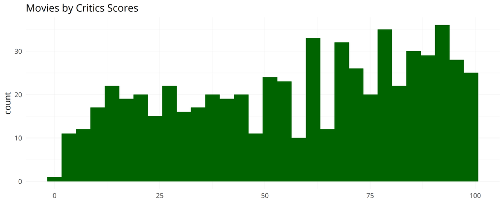

Figure 10: Rotten Tomatoes critics scores

### Rotten Tomatoes Audience Scores

The summary statistics for Rotten Tomatoes audience scores were:  
Table 8

| Min | Q1 | Median | Mean | Q3 | Max | NA.s | SD | IQR | Kurtosis | Skewness |
| --- | --- | --- | --- | --- | --- | --- | --- | --- | --- | --- |
| 11 | 46 | 65 | 62.1 | 80 | 97 | 0 | 20.27 | 34 | -0.93 | -0.34 |

The distribution of audience scores shown in Figure 11 mirrors that of critics scores with slightly less spread than the critics scores.

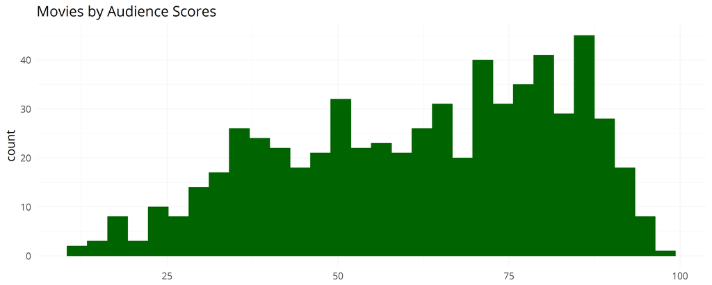

Figure 11: Rotten Tomatoes audience scores

### Best Picture

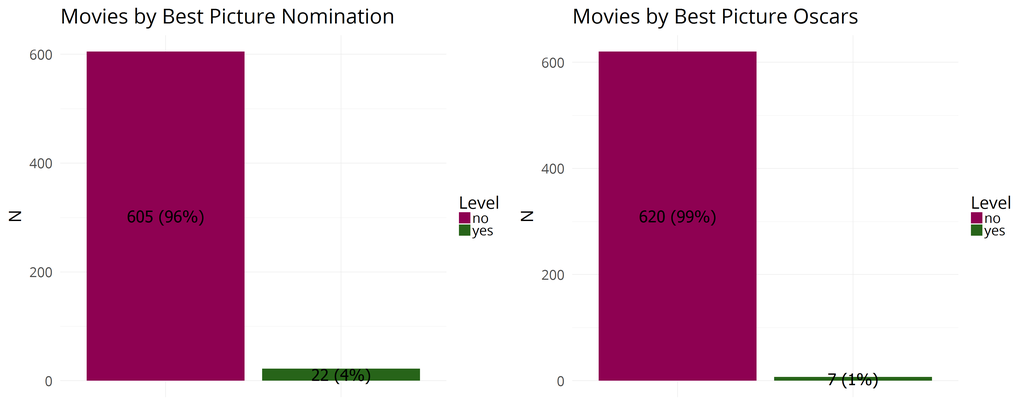

Figure 12: Best picture nominations and wins

### Best Director / Actor / Actress

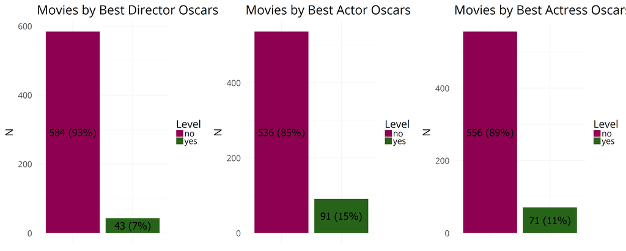

Figure 13: Best director/actor/actress

### Top 200 Box Office

Again, the proportion of films in the Top 200 Box Office list was miniscule indicating that inclusion in the top 200 box office list was not likely to be a good predictor of movie popularity.

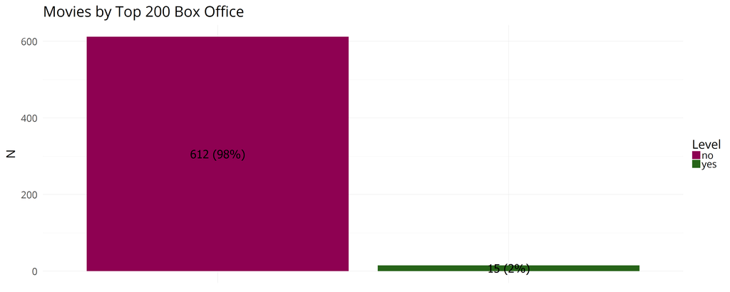

Figure 14: Frequency and proportion of movies by top 200 box office earnings

### Studio Votes

This was a derived variable intended to reflect the popularity of a given studio. Table 9 provides the summary statistics.

Table 9: Total IMDB votes by studio summary statistics

| Min | Q1 | Median | Mean | Q3 | Max | NA.s | SD | IQR | Kurtosis | Skewness |
| --- | --- | --- | --- | --- | --- | --- | --- | --- | --- | --- |
| 183 | 50390.5 | 250669 | 903089.8 | 790665 | 4404677 | 0 | 1347877 | 740274.5 | 1.29 | 1.64 |

The top 10 studios in terms of total IMDB votes are indicated in Table 10.

Table 10: Top 10 studios by IMDB votes

| studio | studio_votes |
| --- | --- |
| Paramount Pictures | 4404677 |
| Warner Bros. Pictures | 3998235 |
| Universal Pictures | 2730054 |
| Miramax Films | 2460066 |
| 20th Century Fox | 2037946 |
| Sony Pictures | 1523421 |
| Buena Vista Pictures | 1257696 |
| Lionsgate | 1073601 |
| The Weinstein Co. | 955291 |
| Newmarket Films | 806911 |

### Total Cast Votes

This derived variable provided a proxy for the individual and collective popularity of the cast for a film. Table 11 provides the summary statistics. Table 11: Total cast IMDB votes per film summary statistics

| Min | Q1 | Median | Mean | Q3 | Max | NA.s | SD | IQR | Kurtosis | Skewness |
| --- | --- | --- | --- | --- | --- | --- | --- | --- | --- | --- |
| 183 | 17866 | 76506.8 | 156740.5 | 226478.2 | 1504872 | 0 | 197381.9 | 208612.2 | 6.62 | 2.18 |

| title | cast_votes |
| --- | --- |
| Django Unchained | 1504872 |
| The Prestige | 1158336 |
| The Godfather, Part II | 1090854 |
| Happy Feet | 957649 |
| Titanic | 944005 |
| Memento | 928438 |
| Good Will Hunting | 883135 |
| The Hunger Games | 873210 |
| Swordfish | 854832 |
| Cloud Atlas | 844978 |

### Studio Experience

The top 10 studios in terms of relative experience Table 14: Top 10 studios by relative experience

| studio | studio_experience |
| --- | --- |
| Paramount Pictures | 37 |
| Warner Bros. Pictures | 30 |
| Sony Pictures Home Entertainment | 27 |
| Universal Pictures | 23 |
| Warner Home Video | 19 |
| 20th Century Fox | 18 |
| Miramax Films | 18 |
| MGM | 16 |
| Twentieth Century Fox Home Entertainment | 14 |
| IFC Films | 13 |

### Director Experience

The top 10 directors in terms of relative experience Table 16: Top 10 directors by relative experience

| director | director_experience |
| --- | --- |
| Martin Scorsese | 4 |
| Oliver Stone | 4 |
| Renny Harlin | 4 |
| James Ivory | 4 |
| Woody Allen | 4 |
| Sidney Lumet | 3 |
| John McTiernan | 3 |
| Howard Zieff | 3 |
| Tony Scott | 3 |
| Richard Donner | 3 |

### Film Cast Experience

The top 10 films in terms of relative cast experience Table 18: Top 10 films by relative cast experience

| title | cast_experience |
| --- | --- |
| Conviction | 15 |
| 21 Grams | 15 |
| Under Fire | 15 |
| The Royal Tenenbaums | 14 |
| The Golden Bowl | 14 |
| Kiss of Death | 14 |
| No Country for Old Men | 14 |
| Seven Pounds | 13 |
| Grosse Pointe Blank | 13 |
| U-Turn | 13 |

## Bivariate Analysis

Here, the relationships between the response variable, movie popularity, and the explanatory variables listed in Table 19 are examined.

Table 19: Candidate predictors

| Variable | Description |
| --- | --- |
| popularity | 10 x imdb_rating + critics_score + audience_score |
| title_type | Type of movie (Documentary, Feature Film, TV Movie) |
| genre | Genre of movie (Action & Adventure, Comedy, Documentary, Drama, Horror, Mystery & Suspense, Other) |
| mpaa_rating | MPAA rating of the movie (G, PG, PG-13, R, Unrated) |
| thtr_rel_season | Season the movie was released in theaters |
| thtr_rel_month | Month the movie is released in theaters |
| imdb_num_votes | Number of votes on IMDB |
| log_imdb_num_votes | Log number of IMDB votes |
| studio_votes | Total IMDB votes per studio |
| cast_votes | Total number of allocated IMDB votes for the cast of a film |
| studio_experience | Total number of films for studio in sample |
| director_experience | Total number of films in sample for a director |
| cast_experience | Relative experience in terms of the sum of the number of film in which each cast member appeared |

### Title Type

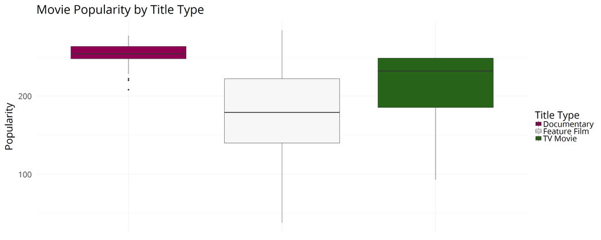

Figure 15: Popularity by title type boxplot

Table 20: Linear model of popularity by title type

| term | estimate | std.error | statistic | p.value |
| --- | --- | --- | --- | --- |
| (Intercept) | 252.25000 | 7.763166 | 32.493184 | 0.000000 |
| xFeature Film | -73.41753 | 8.052739 | -9.117088 | 0.000000 |
| xTV Movie | -50.75000 | 26.892398 | -1.887150 | 0.059604 |

Table 21: Analysis of variance for popularity by title type

| term | df | sumsq | meansq | statistic | p.value |
| --- | --- | --- | --- | --- | --- |
| x | 2 | 221630.5 | 110815.268 | 41.78969 | 0 |
| Residuals | 624 | 1654684.0 | 2651.737 | NA | NA |

### Genre

From Figure 16, the significance of the effect of genre on popularity score was not evident. From the baseline score of 155 for the action & adventure genre, documentaries, dramas, musicals, mysteries and others show significant difference in popularity scores.

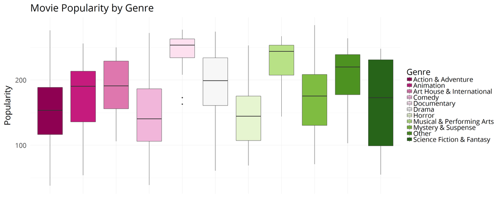

Figure 16: Popularity by genre boxplot

Table 22: Linear model of popularity by genre

| term | estimate | std.error | statistic | p.value |
| --- | --- | --- | --- | --- |
| (Intercept) | 155.218750 | 6.075466 | 25.5484525 | 0.0000000 |
| xAnimation | 16.281250 | 18.226398 | 0.8932786 | 0.3720569 |
| xArt House & International | 33.242789 | 14.786087 | 2.2482478 | 0.0249132 |
| xComedy | -4.648983 | 8.023724 | -0.5794046 | 0.5625280 |
| xDocumentary | 91.709821 | 9.651790 | 9.5018458 | 0.0000000 |
| xDrama | 38.524583 | 6.692211 | 5.7566298 | 0.0000000 |
| xHorror | -9.764204 | 12.012059 | -0.8128668 | 0.4166085 |
| xMusical & Performing Arts | 74.614583 | 15.289587 | 4.8800915 | 0.0000014 |
| xMystery & Suspense | 19.441964 | 8.893571 | 2.1860694 | 0.0291862 |
| xOther | 50.447917 | 13.942720 | 3.6182264 | 0.0003210 |
| xScience Fiction & Fantasy | 3.225694 | 17.302934 | 0.1864247 | 0.8521731 |

Table 23: Analysis of variance for popularity by genre

| term | df | sumsq | meansq | statistic | p.value |
| --- | --- | --- | --- | --- | --- |
| x | 10 | 421124 | 42112.403 | 17.8267 | 0 |
| Residuals | 616 | 1455191 | 2362.322 | NA | NA |

### MPAA Rating

As shown in Figure 17, unrated, rated-G, and NC-17 films were among the most popular; however, the significance of the difference in popularity among the MPAA ratings was not evident.

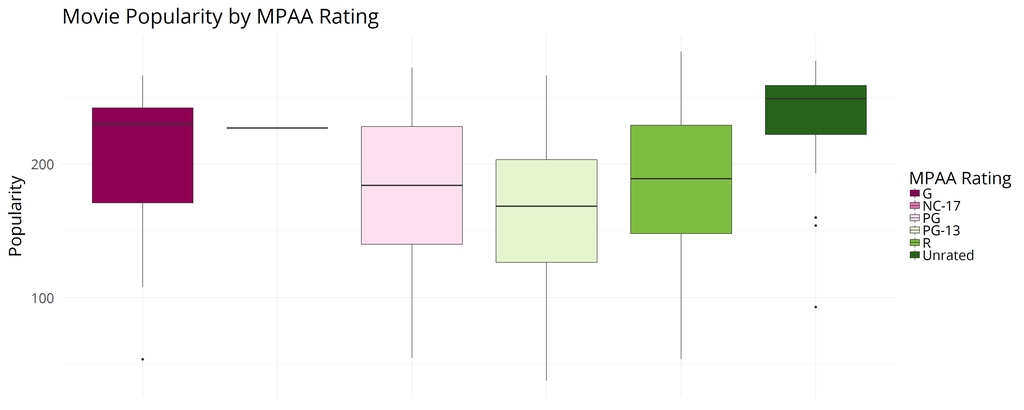

Figure 17: Popularity by mpaa boxplot

Table 24: Linear model of popularity by MPAA rating

| term | estimate | std.error | statistic | p.value |
| --- | --- | --- | --- | --- |
| (Intercept) | 200.52941 | 12.71650 | 15.7692254 | 0.0000000 |
| xNC-17 | 26.47059 | 53.95156 | 0.4906362 | 0.6238571 |
| xPG | -19.81011 | 13.63173 | -1.4532356 | 0.1466635 |
| xPG-13 | -35.39305 | 13.51058 | -2.6196549 | 0.0090170 |
| xR | -15.17739 | 13.04889 | -1.1631171 | 0.2452287 |
| xUnrated | 35.54202 | 15.07194 | 2.3581585 | 0.0186749 |

Table 25: Analysis of variance for popularity by MPAA rating

| term | df | sumsq | meansq | statistic | p.value |
| --- | --- | --- | --- | --- | --- |
| x | 5 | 169147.7 | 33829.546 | 12.30586 | 0 |
| Residuals | 621 | 1707166.8 | 2749.061 | NA | NA |

Table 24 indicates that the most significant differences were among the rated-G, PG-13, and unrated films. The analysis of variance in Table 25 shows that the amount of variance explained by MPAA rating was significant, $F$(5, 621) = 12, $p$ = 0. As such, MPAA rating was considered a significant predictor of movie popularity.

### Season of Theatre Release

As shown in Figure 18, the difference in popularity scores by season of release didn’t appear to be significant.

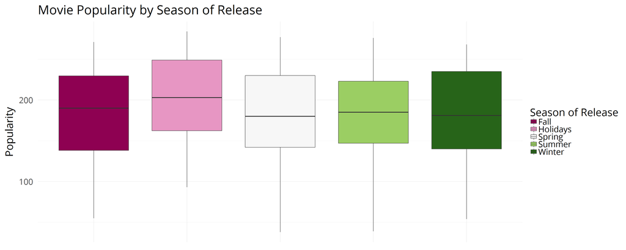

Figure 18: Popularity by season boxplot

Table 26: Linear model of popularity by season rating

| term | estimate | std.error | statistic | p.value |
| --- | --- | --- | --- | --- |
| (Intercept) | 182.132530 | 4.243775 | 42.9175711 | 0.0000000 |
| xHolidays | 16.746258 | 7.956543 | 2.1047153 | 0.0357167 |
| xSpring | -1.468296 | 6.311221 | -0.2326486 | 0.8161109 |
| xSummer | 1.507221 | 6.048021 | 0.2492090 | 0.8032814 |
| xWinter | 1.083965 | 6.987863 | 0.1551211 | 0.8767762 |

Table 27: Analysis of variance for popularity by season rating

| term | df | sumsq | meansq | statistic | p.value |
| --- | --- | --- | --- | --- | --- |
| x | 4 | 16784.31 | 4196.077 | 1.403559 | 0.2312468 |
| Residuals | 622 | 1859530.23 | 2989.598 | NA | NA |

### Month of Theatre Release

As shown in Figure 19, the difference in popularity scores by month of release didn’t appear to be significant.

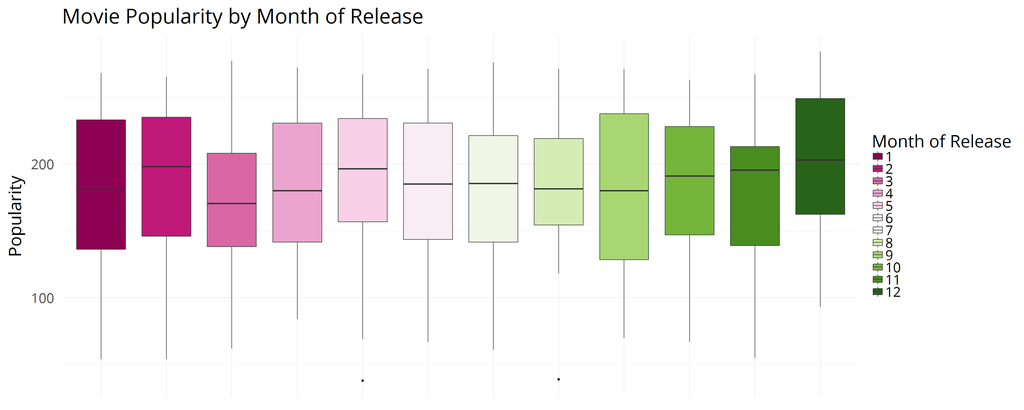

Figure 19: Popularity by month boxplot

Table 28: Linear model of popularity by month rating

| term | estimate | std.error | statistic | p.value |
| --- | --- | --- | --- | --- |
| (Intercept) | 183.0312500 | 6.867053 | 26.6535358 | 0.0000000 |
| x2 | 0.5445076 | 11.773330 | 0.0462492 | 0.9631266 |
| x3 | -7.6912500 | 10.369023 | -0.7417526 | 0.4585204 |
| x4 | -1.7521802 | 10.832484 | -0.1617524 | 0.8715540 |
| x5 | 3.0823864 | 10.758605 | 0.2865043 | 0.7745884 |
| x6 | 1.7856514 | 9.469087 | 0.1885769 | 0.8504866 |
| x7 | -1.6979167 | 10.489597 | -0.1618667 | 0.8714640 |
| x8 | 1.2544643 | 10.909346 | 0.1149899 | 0.9084907 |
| x9 | -1.5410539 | 10.311794 | -0.1494458 | 0.8812509 |
| x10 | 0.8149038 | 9.674056 | 0.0842360 | 0.9328962 |
| x11 | -2.4712500 | 10.369023 | -0.2383301 | 0.8117045 |
| x12 | 15.8475379 | 9.637627 | 1.6443402 | 0.1006170 |

Table 29: Analysis of variance for popularity by month rating

| term | df | sumsq | meansq | statistic | p.value |
| --- | --- | --- | --- | --- | --- |
| x | 11 | 20237.82 | 1839.802 | 0.6096074 | 0.8214345 |
| Residuals | 615 | 1856076.72 | 3018.011 | NA | NA |

The regression output in Table 28 indicates that no significant difference in popularity score among the months. The analysis of variance in Table 29 shows that the amount of variance explained by the month of release was indeed, not significant, $F$(11, 615) = 1, $p$ = 0.821. As such, month of release was not considered a significant predictor of movie popularity.

### IMDB Votes

As shown in Figure 20, a moderately positive relationship between popularity and the number of IMDB scores was extant. The correlation between popularity and number of votes was 0.296.

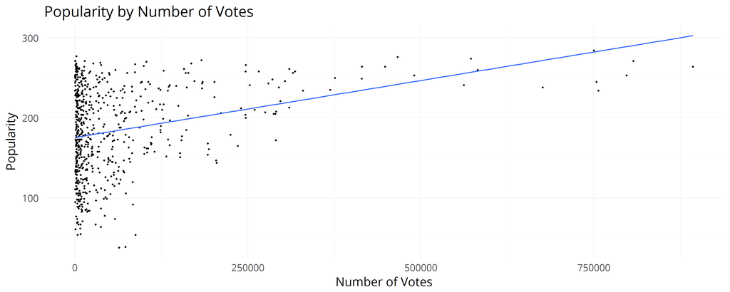

Figure 20: Popularity by votes scatterplot

Table 30: Analysis of variance for popularity by number of IMDB votes

| term | df | sumsq | meansq | statistic | p.value |
| --- | --- | --- | --- | --- | --- |
| x | 1 | 164013.3 | 164013.341 | 59.86583 | 0 |
| Residuals | 625 | 1712301.2 | 2739.682 | NA | NA |

The analysis of variance in Table 30 shows that the amount of variance explained by the number of IMDB votes was significant, $F$(1, 625) = 60, $p$ = 0. As such, the number of IMDB votes was considered a significant predictor of movie popularity.

### IMDB Log Votes

Figure 21, shows a moderately positive relationship between log IMDB votes and popularity with a correlation coefficient of 0.179.

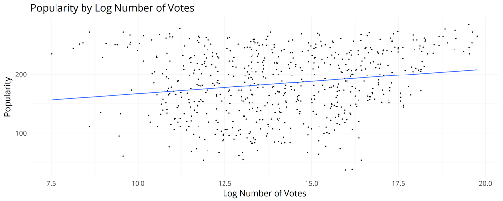

Figure 21: Popularity by logVotes scatterplot

Table 31: Analysis of variance for popularity by number of IMDB logVotes

| term | df | sumsq | meansq | statistic | p.value |
| --- | --- | --- | --- | --- | --- |
| x | 1 | 59895.91 | 59895.91 | 20.60921 | 0.0000068 |
| Residuals | 625 | 1816418.62 | 2906.27 | NA | NA |

The analysis of variance in Table 31 shows that the amount of variance explained by the log number of IMDB votes was significant, $F$(1, 625) = 21, $p$ = 0. As such, the log number of IMDB votes was considered a significant predictor of movie popularity.

### Studio Average Votes

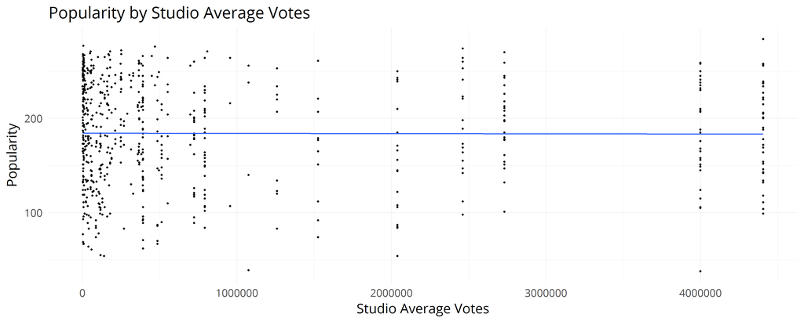

Figure 22: Popularity by studio average votes

Table 32: Analysis of variance for popularity by studio average votes

| term | df | sumsq | meansq | statistic | p.value |
| --- | --- | --- | --- | --- | --- |
| x | 1 | 48.6885 | 48.6885 | 0.0162185 | 0.8987027 |
| Residuals | 625 | 1876265.8474 | 3002.0254 | NA | NA |